# Accessing data from DataONE using R

## Goal of this presentation:

- Promote understanding of DataONE model and architecture
- Illustrate access to DataONE hosted data sets using the R dataone package

Matthew B. Jones, NCEAS, UCSB

# Data in the KNB data repository

[figure not shown]

# With detailed metadata

[figure not shown]

# DataONE Data Flow

[figure not shown]

# Data Packages

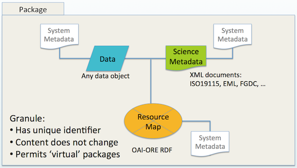

# Displaying a package

[figure not shown]

# R "dataone" library functions

- Search DataONE for data of interest
- Download individual data files and associated metadata
- Download complete data packages (data and metadata)
- Create new data packages on Member Nodes

# Installing the dataone package

- Requires Java is already installed
- install.packages("dataone")
  - May see dependency errors on XML and rJava; we will work those out
  - May need to run: "sudo R CMD javareconf"

# Searching DataONE

- DataONE supports SOLR query syntax
- Results returned are list of data packages
- Includes identifiers for:
  - Package (resource map)
  - Science Metadata
  - Data objects

# Search results

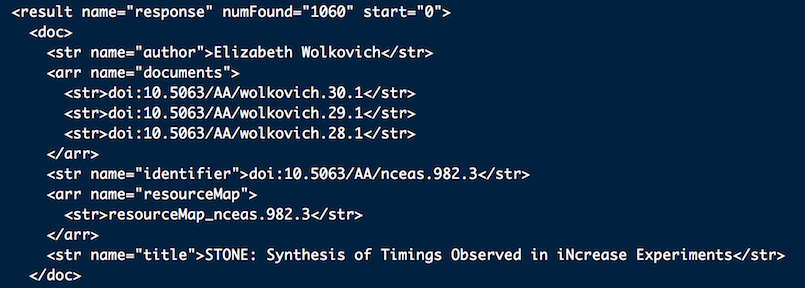

# Downloading data and packages

- getD1Object()
- getDataPackage()

# Authentication using CILogon

- Allows access to restricted objects
- Allows creation of content on appropriate nodes
- CILogon provides authentication through a many current University partners
- https://cilogon.org/?skin=DataONE
- Saves a certificate on your hard drive that the R dataone library finds

# Writing data to DataONE Member Nodes

- Write data to nodes that provide write service
  - e.g., KNB
- Steps
  - Load the data frame in R
  - Generate or request an identifier for the object
  - Convert it to CSV format
  - Make an instance of D1Object class containing the data
  - Mark the object as publicly accessible
  - Upload the object to the KNB by calling the createD1Object() method